# Nonlinear Models - Project 2

# Nonlinear Models

Using the several data sets created from our previous transformations we attempted to fit several non-linear models. Specifically, a Neural Network and MARS model. While data transformations are not always necessary for the MARS method, we will nonetheless benefit from removing data features that would be adding unncessary noise to our final models. The Neural Network can be greatly impacted by highly correlated variables.

## Neural Network

Neural Networks can be thought of as models that work in similar ways to our brain. Inputs are provided and transformed at nodes by assigned weights that then feed-forward to any additional layers containing additional nodes [^1]. A drawback to this method is that without limitations on our linear combinations from one layer to another, the coefficients will have little context [^3].

In the below code snippet, we set our seed for reproducibility, then we set `trainControl` for 3 repeats of the cross validated method and keep our resamples by setting `returnResamp = "all"`. We then manually tune our grid with the `expand.grid` function and set the Weight Decay via `.decay`, the Hidden Units via `.size`, and then prevent Bagging since we have sufficiently preprocessed our data `.bag = FALSE`. Also, since we are preforming a regression and not a classfication we set `linout` to `TRUE`.

[1] Bishop, Christopher M. Neural Networks for Pattern Recognition. Oxford???: New York: Clarendon Press???; Oxford University Press, 1995.

[3] Kuhn, Max, and Kjell Johnson. Applied Predictive Modeling. New York: Springer, 2013.

```r
set.seed(1234)

nnet <- function(df, y){

              fitControl <- trainControl(method = "cv",
                                         number = 3,
                                         returnResamp = "all")

              nnetGrid <- expand.grid(.decay = c(0, 0.01, .1, .5),
                                      .size = c(5:15),
                                      .bag = FALSE)

                 return(train(df, y,
                              method = "avNNet",
                              tuneGrid = nnetGrid,
                              trControl = fitControl,
                              trace = FALSE,
                              linout = TRUE))
}

nnet.fit.bcsx <- nnet(dfTrainBCSX, dfTrainY)
nnet.fit.bx   <- nnet(dfTrainBX,   dfTrainY)
nnet.fit.x    <- nnet(dfTrainX,    dfTrainY)
```

Now that we have trained our models on the available data sets, we will measure the root mean squared error of all three and select the lowest.

```r
list(RMSE_NNET.BCSX = RMSE(predict(nnet.fit.bcsx, dfTestBCSX), dfTestY),
     RMSE_NNET.BCS  = RMSE(predict(nnet.fit.bx,   dfTestBX), dfTestY),
     RMSE_NNET.X    = RMSE(predict(nnet.fit.x,    dfTestX), dfTestY))
```

```
$RMSE_NNET.BCSX
[1] 0.1182677

$RMSE_NNET.BCS
[1] 0.1550596

$RMSE_NNET.X
[1] 0.1407773
```

Based on our RMSE results the final model chosen for the neural network is `nnet.fit.bcsx`

```r
nnet.fit.bcsx$finalModel
```

```
Model Averaged Neural Network with 5 Repeats

a 20-11-1 network with 243 weights
options were - linear output units
```

Further, we see that `X` and `Mnf.Flow` are the variables with the greatest importance in the model.

```r
varImp(nnet.fit.bcsx)
```

```
loess r-squared variable importance

              Overall
X             100.000
Mnf.Flow       86.463
Filler.Speed   49.488
Filler.Level   42.865
Usage.cont     33.177
Hyd.Pressure1  24.689
Carb.Flow      24.557
Hyd.Pressure2  23.417
C              22.814
Oxygen.Filler  21.224
Hyd.Pressure4  16.019
Density        15.534
B              10.433
PC.Volume       5.387
PSC             4.496
A               1.658
PSC.CO2         1.274
PSC.Fill        0.976
MFR             0.000
D               0.000
```

The grid parameters we set earlier are plotted below to visualize how tuning impacts the model performance.

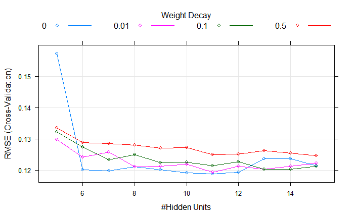

```r
plot(nnet.fit.bcsx)
```

## MARS Model

The Multivariate Adaptive Regression Splines or “MARS” model is a nonparametric method, i.e. we are not required to make any assumptions about any underlying distributions such as the neural network. It can achieve this by pivoting on naturally occuring breaks in the data set and essentially building a model out of many linear models developed for specific segemets of the data set [^2] [^3].

[2] J.H. Friedman, “Multivariate adaptive regression splines”, The Annals of Statistics, 19 (1991), pp. 1-141

[3] Kuhn, Max, and Kjell Johnson. Applied Predictive Modeling. New York: Springer, 2013.

```r
library(caret)

set.seed(1234)

mars <- function(df, y){

          fitControl <- trainControl(method = "cv",
                                     number = 3,
                                     returnResamp = "all")

          MARSGrid <- expand.grid(degree= 3:5,
                                  nprune = seq(20,60,20))

          return(train(df, y,
                 method = "earth",
                 tuneGrid = MARSGrid,
                 trControl = fitControl))
         }

mars.fit.bcsx <- mars(dfTrainBCSX, dfTrainY)
mars.fit.bx   <- mars(dfTrainBX,   dfTrainY)
mars.fit.x    <- mars(dfTrainX,    dfTrainY)
```

Now that we have trained our models on the available data sets, we will measure the root mean squared error of all three and select the lowest.

```r
list(RMSE_MARS.BCSX = RMSE(predict(mars.fit.bcsx, dfTestBCSX), dfTestY),
     RMSE_MARS.BCS  = RMSE(predict(mars.fit.bx,   dfTestBX), dfTestY),
     RMSE_MARS.X    = RMSE(predict(mars.fit.x,    dfTestX), dfTestY))
```

```
$RMSE_MARS.BCSX
[1] 0.1218774

$RMSE_MARS.BCS
[1] 0.1131589

$RMSE_MARS.X
[1] 0.1260135
```

The model fitted to the mars.fit.bx preformed the best and is further selected to be evaluated. The model results are provided below.

```r
mars.fit.bx$finalModel
```

```
Selected 39 of 48 terms, and 15 of 36 predictors
Termination condition: Reached maximum RSq 0.9990 at 48 terms
Importance: Mnf.Flow, C, X, Temperature, Air.Pressurer, Filler.Speed, Density, Oxygen.Filler, D, ...
Number of terms at each degree of interaction: 1 9 16 11 2
GCV 0.01211891    RSS 21.09636    GRSq 0.5952478    RSq 0.6341722
```

The below figure provides insight into the tuning parameters. We can see that our 5 degree model begins to outperform our 4 degree model at the max of 40 terms but the 4 degree model outperforms the 5 degree model at the 60 maximum terms.

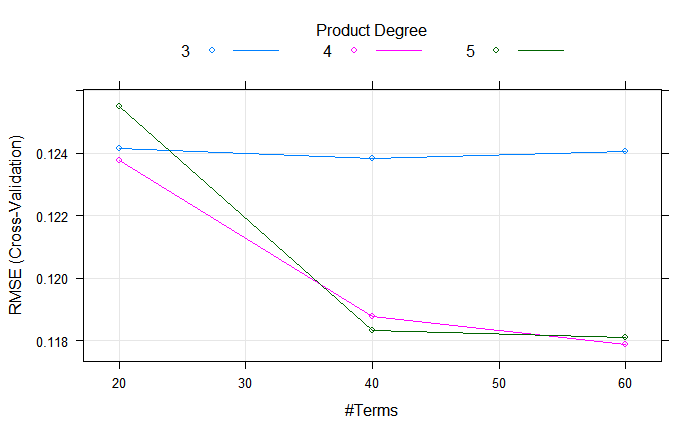

```r
plot(mars.fit.bx)
```

In our final MARS model, the variable of greatest importance is `Mnf.Flow`.

```r
varImp(mars.fit.bx)
```

```
earth variable importance

  only 20 most important variables shown (out of 36)

                Overall
Mnf.Flow         100.00
C                 81.67
X                 74.73
Temperature       63.89
Air.Pressurer     63.89
Oxygen.Filler     54.50
Filler.Speed      52.43
Density           52.43
D                 49.52
Carb.Pressure1    45.23
Carb.Rel          45.23
Alch.Rel          30.39
Balling           29.13
Pressure.Vacuum   21.28
Carb.Volume       11.80
Balling.Lvl        0.00
Hyd.Pressure2      0.00
Filler.Level       0.00
PSC                0.00
Fill.Pressure      0.00
```

# Model Choice

```r
list(RMSE_MARS = RMSE(predict(mars.fit.bx, dfTestBX), dfTestY),
     RMSE_NNET = RMSE(predict(nnet.fit.bcsx, dfTestBCSX), dfTestY))
```

```
$RMSE_MARS
[1] 0.1131589

$RMSE_NNET
[1] 0.1182677
```